# p8130_hw4_jsg2145

Jared Garfinkel

11/16/2019

## Problem 3

```
##
## Call:
## lm(formula = glia_neuron_ratio ~ ln_brain_mass, data = .)
##
## Coefficients:
##   (Intercept)  ln_brain_mass
##        0.1637         0.1811
```

## Problem 3a

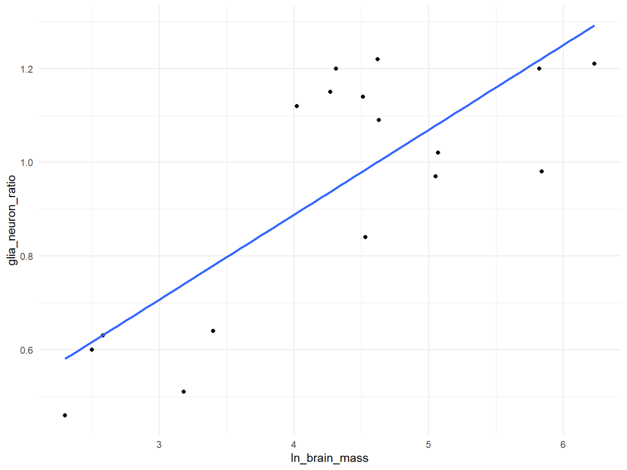

```
##
## Call:
## lm(formula = glia_neuron_ratio ~ ln_brain_mass, data = .)
##
## Residuals:
##      Min       1Q   Median       3Q      Max
## -0.24150 -0.12030 -0.01787  0.15940  0.25563
##
## Coefficients:
##               Estimate Std. Error t value Pr(>|t|)
## (Intercept)    0.16370    0.15987   1.024 0.322093
## ln_brain_mass  0.18113    0.03604   5.026 0.000151 ***
## ---
## Signif. codes:  0 '***' 0.001 '**' 0.01 '*' 0.05 '.' 0.1 ' ' 1
##
## Residual standard error: 0.1699 on 15 degrees of freedom
## Multiple R-squared:  0.6274, Adjusted R-squared:  0.6025
## F-statistic: 25.26 on 1 and 15 DF,  p-value: 0.0001507
```

```
##        1
## 1.471458
```

## Problem 3b

The predicted glia-neuron ratio for humans given the non human data is 1.47.

## Problem 3c

The interval for the mean glia-neuron ratio at the given brain mass is preferable because it

takes into account the data we have observed.

## Problem 3d

$\hat{Y_h} = b_0 + b_1*X_h$

$$s^2(\hat{Y_h}) = MSE\left [\frac{1}{n} + \frac{(X_h-\bar{X})^2}{\sum{(X_i - \bar{X})^2}}\right]$$

= 0.0344706

s = $\sqrt{s^2} = \sqrt{.034}$ = 0.1843909

95% CI:
$$\hat{Y_h} \pm t_{1-\alpha/2,~n-2}*s(\hat{Y_H})$$

= 1.47 $\pm t_{.975,~15}*0.18$

= 1.47 $\pm$ 2.1314495 * 0.18

Since the human glia nueron ratio is within the 95% confidence interval of the predicted response

there is no evidence that the human brain has an excessive glia-neuron ratio compared with

other primates.

```
##        fit      lwr      upr
## 1 1.471458 1.036047 1.906869
```

## Problem 3e

This is extrapolation since the prediction is outside the observed range. Extrapolation can

provide accurate results when the prediction is close to the observed data. However, it may

not be a good idea if the prediction is far from the observed data.

# Problem 4

##Problem 4a

This dataset is 788 rows long and 10 columns across. It records

observations about patients diagnosed with heart disease. The main variables are total cost and

number of emergency room visits. Other variables of interest are age, gender, complications, and

duration of treatment. Other variables includes the number of drugs prescribed, and the number of

comorbidities diagnosed.

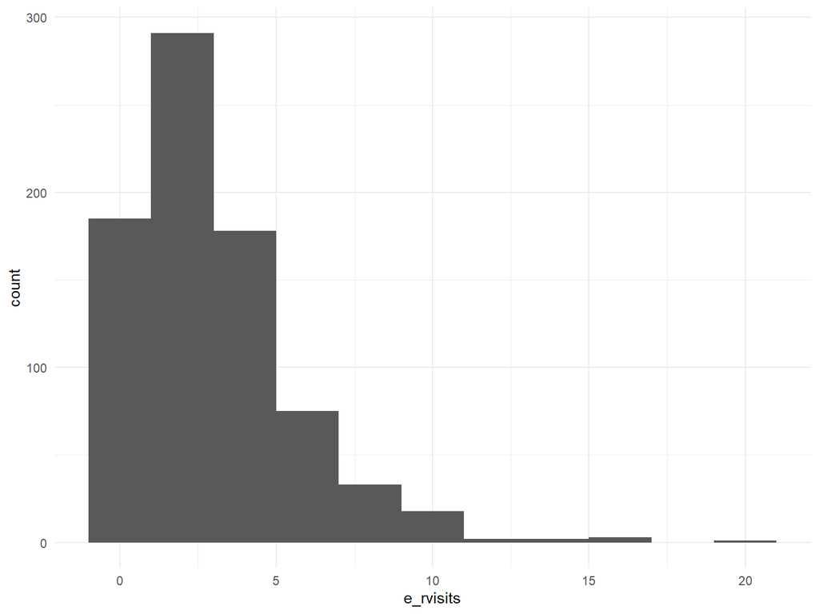

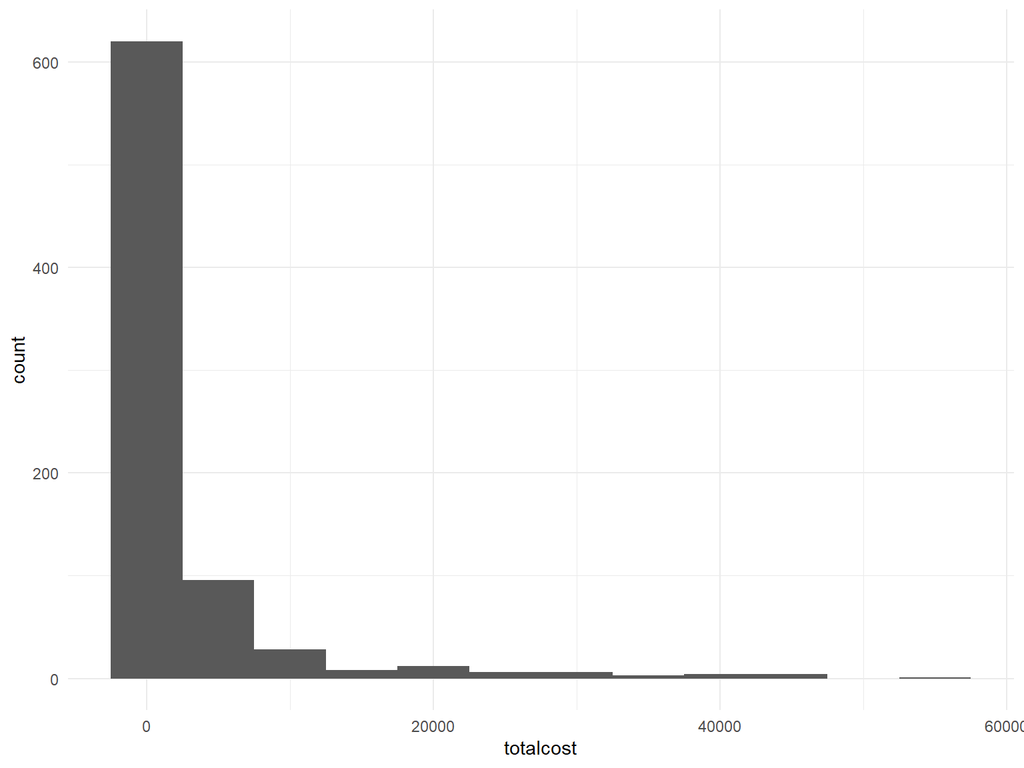

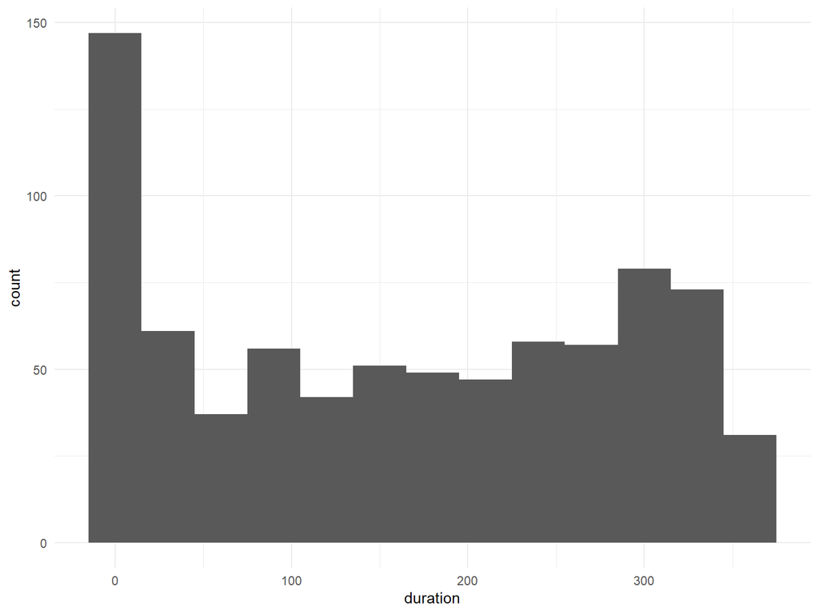

## Problem 4b

The values of total cost are not normally distributed. One applies a log transformation.

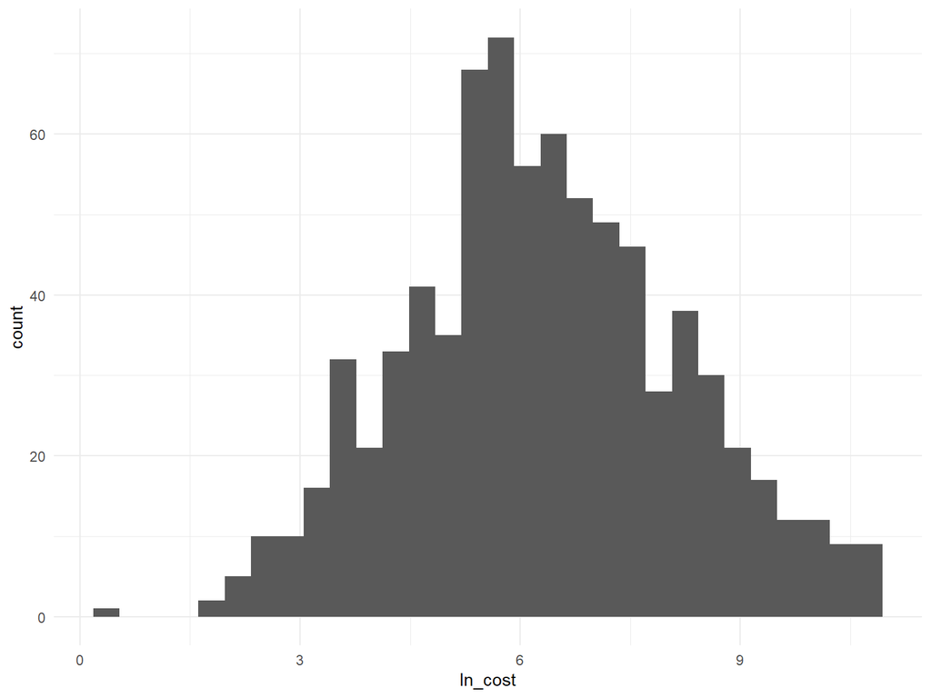

```
## # A tibble: 788 x 11
##       id totalcost   age gender interventions drugs e_rvisits complications
##    <dbl>     <dbl> <dbl>  <dbl>         <dbl> <dbl>     <dbl>         <dbl>
##  1     1      179.    63      0             2     1         4             0
##  2     2      319     59      0             2     0         6             0
##  3     3     9311.    62      0            17     0         2             0
##  4     4      281.    60      1             9     0         7             0
##  5     5    18727.    55      0             5     2         7             0
##  6     6      453.    66      0             1     0         3             0
##  7     7      323.    64      1             2     0         3             0
##  8     8     3874.    45      1             3     0         5             0
##  9     9     3244.    68      0             6     2         5             0
## 10    10      226.    64      1             3     0         2             0
## # ... with 778 more rows, and 3 more variables: comorbidities <dbl>,
## #   duration <dbl>, comp_bin <dbl>
```

## Problem 4c

Add variables for the log of total cost and comp_bin.

## Problem 4d

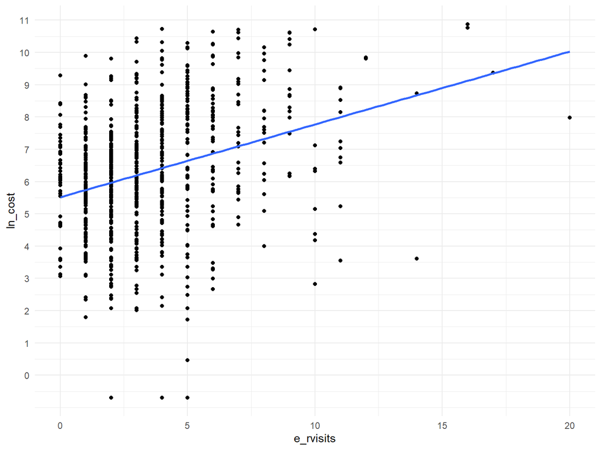

```
##
## Call:
## lm(formula = ln_cost ~ e_rvisits, data = .)
##
## Coefficients:
## (Intercept)    e_rvisits
##      5.5147       0.2256
```

To interpret this, one may back transform the slope by raising the natural number, $e$, to the power

of the slope. So, for each emergency room visit, there is a $e^{.2256}$ times rise in cost. In other

words, there is an $e^{.2256}-1$ percent rise in cost for each emergency room visit. This is equivalent

to 25.3074335 %.

```
##
## Call:
## lm(formula = ln_cost ~ e_rvisits, data = .)
##
## Residuals:
##     Min      1Q  Median      3Q     Max
## -7.3358 -1.1168  0.0395  1.2899  4.3073
##
## Coefficients:
##             Estimate Std. Error t value Pr(>|t|)
## (Intercept)  5.51469    0.10642  51.818   <2e-16 ***
## e_rvisits    0.22559    0.02462   9.161   <2e-16 ***
## ---
## Signif. codes:  0 '***' 0.001 '**' 0.01 '*' 0.05 '.' 0.1 ' ' 1
##
## Residual standard error: 1.822 on 786 degrees of freedom
## Multiple R-squared:  0.09648,    Adjusted R-squared:  0.09533
## F-statistic: 83.93 on 1 and 786 DF,  p-value: < 2.2e-16
```

This summary table shows the adjusted r-squared value is less than 0.1, indicating that the number of

emergency room visits alone is a poor predictor for the total cost for a patient.

## Problem 4e

```
##
## Call:
## lm(formula = ln_cost ~ e_rvisits + comp_bin, data = .)
##
## Residuals:
##     Min      1Q  Median      3Q     Max
## -7.2067 -1.0717  0.0017  1.1957  4.4139
##
## Coefficients:
##             Estimate Std. Error t value Pr(>|t|)
## (Intercept)  5.49804    0.10411  52.809  < 2e-16 ***
## e_rvisits    0.20311    0.02436   8.336 3.42e-16 ***
## comp_bin     1.71655    0.28273   6.071 1.98e-09 ***
## ---
## Signif. codes:  0 '***' 0.001 '**' 0.01 '*' 0.05 '.' 0.1 ' ' 1
##
## Residual standard error: 1.782 on 785 degrees of freedom
## Multiple R-squared:  0.137,  Adjusted R-squared:  0.1348
## F-statistic: 62.31 on 2 and 785 DF,  p-value: < 2.2e-16
```

After back transforming on a log-scale, this summary table indicates that there is

an 1.225195 times increase in the total cost for a patient per emergency room, or 22.5194982 visit and

a 5.5655733 times increase in the total cost (456.557331 %) if there

is a complication during treatment.

### Problem 4ei

```
##
## Call:
## lm(formula = ln_cost ~ e_rvisits * comp_bin, data = .)
##
## Residuals:
##    Min     1Q Median     3Q    Max
## -7.218 -1.077  0.013  1.210  4.410
##
## Coefficients:
##                    Estimate Std. Error t value Pr(>|t|)
## (Intercept)         5.47630    0.10635  51.492  < 2e-16 ***
## e_rvisits           0.20964    0.02522   8.312 4.15e-16 ***
## comp_bin            2.20238    0.56160   3.922 9.57e-05 ***
## e_rvisits:comp_bin -0.09765    0.09754  -1.001    0.317
## ---
## Signif. codes:  0 '***' 0.001 '**' 0.01 '*' 0.05 '.' 0.1 ' ' 1
##
## Residual standard error: 1.782 on 784 degrees of freedom
## Multiple R-squared:  0.1381, Adjusted R-squared:  0.1348
## F-statistic: 41.88 on 3 and 784 DF,  p-value: < 2.2e-16
```

To determine whether complications are an effect modifier of the association of number of emergency

room visits with total cost, one determines if there is a significant difference in the estimated

slope: (.20964 - .22559)/.22559 = -0.01595/.22559 = -0.0707035. A

cutoff of ten percent is used, so this is not an effect modifier.

### Problem 4eii

To determine whether complications are a confounder of the relationship between number of emergency

room visits and total cost, there must be an association between the confounder and the exposure,

being number of emergency room visits.

```
##
## Call:
## lm(formula = e_rvisits ~ comp_bin, data = .)
##
## Residuals:
##     Min      1Q  Median      3Q     Max
## -5.0930 -1.3289 -0.3289  0.6711 16.6711
##
## Coefficients:
##             Estimate Std. Error t value Pr(>|t|)
## (Intercept)  3.32886    0.09557  34.833  < 2e-16 ***
## comp_bin     1.76416    0.40911   4.312 1.82e-05 ***
## ---
## Signif. codes:  0 '***' 0.001 '**' 0.01 '*' 0.05 '.' 0.1 ' ' 1
##
## Residual standard error: 2.608 on 786 degrees of freedom
## Multiple R-squared:  0.02311,    Adjusted R-squared:  0.02187
## F-statistic:  18.6 on 1 and 786 DF,  p-value: 1.822e-05
```

This summary table shows taht there is a 1.76 increase in the number of emergency room visits if

a complication occurs. However, the adjusted r-squared value indicates that a complication is a poor

predictor of the number of emergency room visits. So, complication is probably not a confounder. On

the other hand, the model including complications indicates there is a significant difference in the

estimated slope: (.20311 - .22559)/.22559 = -0.02248/.22559 = -0.0996498.

Using a cutoff of 10%, this number is quite close.

### Problem 4eiii

Since the presence of a complication was close to the cutoff for being a confounder and it

## Problem 4f

```
##
## Call:
## lm(formula = ln_cost ~ e_rvisits + comp_bin + age + gender +
##     duration, data = .)
##
## Residuals:
##     Min      1Q  Median      3Q     Max
## -6.1297 -1.0336 -0.1036  0.9586  4.3480
##
## Coefficients:
##               Estimate Std. Error t value Pr(>|t|)
## (Intercept)  5.9240310  0.5167617  11.464  < 2e-16 ***
## e_rvisits    0.1744731  0.0228547   7.634 6.64e-14 ***
## comp_bin     1.5126547  0.2617067   5.780 1.08e-08 ***
## age         -0.0207402  0.0087826  -2.362   0.0184 *
## gender      -0.2191600  0.1404272  -1.561   0.1190
## duration     0.0057983  0.0004949  11.715  < 2e-16 ***
## ---
## Signif. codes:  0 '***' 0.001 '**' 0.01 '*' 0.05 '.' 0.1 ' ' 1
##
## Residual standard error: 1.644 on 782 degrees of freedom
## Multiple R-squared:  0.268,  Adjusted R-squared:  0.2633
## F-statistic: 57.26 on 5 and 782 DF,  p-value: < 2.2e-16
```

```
## Analysis of Variance Table
##
## Model 1: ln_cost ~ e_rvisits + comp_bin
## Model 2: ln_cost ~ e_rvisits + comp_bin + age + gender + duration
##   Res.Df    RSS Df Sum of Sq      F    Pr(>F)
## 1    785 2492.1
## 2    782 2113.9  3    378.24 46.642 < 2.2e-16 ***
## ---
## Signif. codes:  0 '***' 0.001 '**' 0.01 '*' 0.05 '.' 0.1 ' ' 1
```

### Problem 4fi

The MLR method using the variables for the number of emergency room visits, the presence of a

complication, age, gender, and duration of treatment raises the adjusted r-squared by a factor of 2.

While the number of emergency room visits, the presence of a complication and the duration of treatment

are associated with increased cost, age and being female are associated with a decrease in cost.

Gender and age account for a relatively low proportion of the adjusted r-squared

in the log cost. While duration accounts for a significant portion of the adjusted r-squared, the

effect is very low - duration of treatment increases the price predictably, but at a very low rate. The

cost to a patient would increase about 0.6% ($(e^{.0057983}-1)\times100$% = 0.5815143%)

per day. On the first day of the stay, a one day increase in length of stay is associated with an

average increase in cost of about two dollars and a quarter ($e^{\beta_0}\times e^{\beta_1*x}-e^{\beta_0}$)

= $e^{5.924} \times e^{0.005798}-e^{5.924}$ = 2.1741943.

On the one-hundredth day it is associated with an increase of $e^{5.924} \times e^{0.005798*100}-e^{5.924} \times e^{0.005798*99}$

= 3.8599729 or about four dollars.

### Problem 4fii

Even though there is evidence to suggest the complex model accounts for more of the variability in

our model according to a partial F-test, there is reason to believe a simple model may be more

useful in practice.

Since the model with the number of emergency room visits and complications accounts for nearly half

of the adjusted r-squared with three fewer variables, it may be more informative to include only these

two variables.